# Probabilistic Interpolation

HES 505 Fall 2025: Session 20

Matt Williamson

## Interpolation

> Spatial interpolation is the process of predicting values of a target variable or attribute at an unobserved location, from a set of values at known (observed) locations

## Deterministic vs. Probabalistic Interpolation

- **Deterministic**- interpolated values calculated as a function of distance
- **Probabilistic**- interpolated values are *predicted* based on statistical models

## Kriging

- Previous methods predict $z$ as a (weighted) function of distance
- Treat the observations as perfect (no error)
- If we imagine that $z$ is the outcome of some spatial process such that:

$$\begin{equation}
z(\mathbf{x}) = \mu(\mathbf{x}) + \epsilon(\mathbf{x})
\end{equation}$$

then any observed value of $z$ is some function of the process ($\mu(\mathbf{x})$) and some error ($\epsilon(\mathbf{x})$)

- Kriging exploits autocorrelation in $\epsilon(\mathbf{x})$ to identify the trend and interpolate accordingly

## Autocorrelation

- **Correlation** the tendency for two variables to be related
- **Autocorrelation** the tendency for observations that are closer (in space or time) to be correlated
- **Positive autocorrelation** neighboring observations have $\epsilon$ with the same sign
- **Negative autocorrelation** neighboring observations have $\epsilon$ with a different sign (rare in geography)

## Ordinary Kriging

- Assumes that the deterministic part of the process ($\mu(\mathbf{x})$) is an unknown constant ($\mu$)

$$\begin{equation}
z(\mathbf{x}) = \mu + \epsilon(\mathbf{x})
\end{equation}$$

## (semi)Variograms

- Relationship between observation variance and distance
- **nugget** - the proportion of semivariance that occurs at small distances
- **sill** - the maximum semivariance between pairs of observations
- **range** - the distance at which the **sill** occurs

## Variograms

- Empirical vs. fitted.

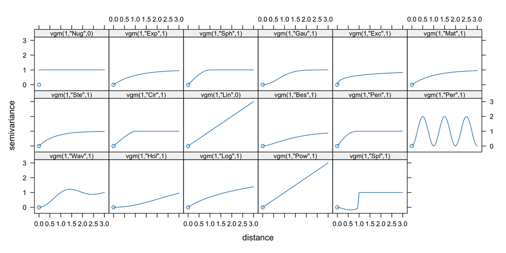

## Universal Kriging

- Assumes that the deterministic part of the process ($\mu(\mathbf{x})$) is now a function of the location $\mathbf{x}$
- Could be the location or some other attribute
- Now `y` is a function of some aspect of `x`

## Co-Kriging

- relies on autocorrelation in $\epsilon_1(\mathbf{x})$ for $z_1$ AND cross correlation with other variables ($z_{2...j}$)
- Extending the ordinary kriging model gives:

$$\begin{equation}
z_1(\mathbf{x}) = \mu_1 + \epsilon_1(\mathbf{x})\\
z_2(\mathbf{x}) = \mu_2 + \epsilon_2(\mathbf{x})
\end{equation}$$

- Note that there is autocorrelation within both $z_1$ and $z_2$ (because of the $\epsilon$) and cross-correlation (because of the location, $\mathbf{x}$)
- Not required that all variables are measured at exactly the same points

## Why Krig?

- Allows empirical estimate of autocorrelation
- Incorporate actual spatial structure
- Increased accuracy
- Uncertainty estimates

## Why Not Krig?

- Computationally intensive
- Smoothing not guarenteed
- Variograms (somewhat) subjective